# Risk Factor Analysis

## Outcome Variable

**Outcome Variable:** pers_wast

## Predictor Variables

**Intervention Variable:** mbmi

**Adjustment Set:**

- arm
- W_mage
- meducyrs
- feducyrs
- single
- brthmon
- W_parity
- delta_W_mage
- delta_meducyrs
- delta_feducyrs
- delta_single
- delta_brthmon
- delta_W_parity

## Stratifying Variables

The analysis was stratified on these variable(s):

- agecat
- studyid
- country

## Data Summary

| agecat | studyid | country | mbmi | pers_wast | n_cell | n |
| --- | --- | --- | --- | --- | --- | --- |
| 0-24 months | iLiNS-Zinc | BURKINA FASO | Normal weight | 0 | 1269 | 1645 |
| 0-24 months | iLiNS-Zinc | BURKINA FASO | Normal weight | 1 | 146 | 1645 |
| 0-24 months | iLiNS-Zinc | BURKINA FASO | Underweight | 0 | 183 | 1645 |
| 0-24 months | iLiNS-Zinc | BURKINA FASO | Underweight | 1 | 47 | 1645 |
| 0-24 months | JiVitA-3 | BANGLADESH | Normal weight | 0 | 9213 | 15759 |
| 0-24 months | JiVitA-3 | BANGLADESH | Normal weight | 1 | 501 | 15759 |
| 0-24 months | JiVitA-3 | BANGLADESH | Underweight | 0 | 5651 | 15759 |
| 0-24 months | JiVitA-3 | BANGLADESH | Underweight | 1 | 394 | 15759 |
| 0-24 months | LCNI-5 | MALAWI | Normal weight | 0 | 595 | 716 |
| 0-24 months | LCNI-5 | MALAWI | Normal weight | 1 | 4 | 716 |
| 0-24 months | LCNI-5 | MALAWI | Underweight | 0 | 115 | 716 |
| 0-24 months | LCNI-5 | MALAWI | Underweight | 1 | 2 | 716 |
| 0-24 months | MAL-ED | BANGLADESH | Normal weight | 0 | 208 | 248 |
| 0-24 months | MAL-ED | BANGLADESH | Normal weight | 1 | 8 | 248 |
| 0-24 months | MAL-ED | BANGLADESH | Underweight | 0 | 27 | 248 |
| 0-24 months | MAL-ED | BANGLADESH | Underweight | 1 | 5 | 248 |
| 0-24 months | MAL-ED | BRAZIL | Normal weight | 0 | 204 | 216 |
| 0-24 months | MAL-ED | BRAZIL | Normal weight | 1 | 2 | 216 |
| 0-24 months | MAL-ED | BRAZIL | Underweight | 0 | 10 | 216 |
| 0-24 months | MAL-ED | BRAZIL | Underweight | 1 | 0 | 216 |
| 0-24 months | MAL-ED | INDIA | Normal weight | 0 | 177 | 240 |
| 0-24 months | MAL-ED | INDIA | Normal weight | 1 | 14 | 240 |
| 0-24 months | MAL-ED | INDIA | Underweight | 0 | 42 | 240 |
| 0-24 months | MAL-ED | INDIA | Underweight | 1 | 7 | 240 |
| 0-24 months | MAL-ED | NEPAL | Normal weight | 0 | 234 | 238 |
| 0-24 months | MAL-ED | NEPAL | Normal weight | 1 | 4 | 238 |
| 0-24 months | MAL-ED | NEPAL | Underweight | 0 | 0 | 238 |
| 0-24 months | MAL-ED | NEPAL | Underweight | 1 | 0 | 238 |
| 0-24 months | MAL-ED | PERU | Normal weight | 0 | 277 | 283 |
| 0-24 months | MAL-ED | PERU | Normal weight | 1 | 1 | 283 |

[output cut: 162 more lines]

The following strata were considered:

- agecat: 0-24 months, studyid: iLiNS-Zinc, country: BURKINA FASO
- agecat: 0-24 months, studyid: JiVitA-3, country: BANGLADESH
- agecat: 0-24 months, studyid: LCNI-5, country: MALAWI
- agecat: 0-24 months, studyid: MAL-ED, country: BANGLADESH
- agecat: 0-24 months, studyid: MAL-ED, country: BRAZIL
- agecat: 0-24 months, studyid: MAL-ED, country: INDIA
- agecat: 0-24 months, studyid: MAL-ED, country: NEPAL
- agecat: 0-24 months, studyid: MAL-ED, country: PERU
- agecat: 0-24 months, studyid: MAL-ED, country: SOUTH AFRICA
- agecat: 0-24 months, studyid: MAL-ED, country: TANZANIA, UNITED REPUBLIC OF
- agecat: 0-24 months, studyid: NIH-Birth, country: BANGLADESH
- agecat: 0-24 months, studyid: NIH-Crypto, country: BANGLADESH
- agecat: 0-24 months, studyid: PROBIT, country: BELARUS
- agecat: 0-24 months, studyid: PROVIDE, country: BANGLADESH
- agecat: 0-24 months, studyid: SAS-CompFeed, country: INDIA
- agecat: 0-24 months, studyid: TanzaniaChild2, country: TANZANIA, UNITED REPUBLIC OF
- agecat: 0-24 months, studyid: ZVITAMBO, country: ZIMBABWE
- agecat: 0-6 months, studyid: JiVitA-3, country: BANGLADESH
- agecat: 0-6 months, studyid: MAL-ED, country: BANGLADESH
- agecat: 0-6 months, studyid: MAL-ED, country: BRAZIL
- agecat: 0-6 months, studyid: MAL-ED, country: INDIA
- agecat: 0-6 months, studyid: MAL-ED, country: NEPAL
- agecat: 0-6 months, studyid: MAL-ED, country: PERU
- agecat: 0-6 months, studyid: MAL-ED, country: SOUTH AFRICA
- agecat: 0-6 months, studyid: MAL-ED, country: TANZANIA, UNITED REPUBLIC OF
- agecat: 0-6 months, studyid: NIH-Birth, country: BANGLADESH
- agecat: 0-6 months, studyid: NIH-Crypto, country: BANGLADESH
- agecat: 0-6 months, studyid: PROBIT, country: BELARUS
- agecat: 0-6 months, studyid: PROVIDE, country: BANGLADESH
- agecat: 0-6 months, studyid: TanzaniaChild2, country: TANZANIA, UNITED REPUBLIC OF
- agecat: 0-6 months, studyid: ZVITAMBO, country: ZIMBABWE
- agecat: 6-24 months, studyid: iLiNS-Zinc, country: BURKINA FASO
- agecat: 6-24 months, studyid: JiVitA-3, country: BANGLADESH
- agecat: 6-24 months, studyid: LCNI-5, country: MALAWI
- agecat: 6-24 months, studyid: MAL-ED, country: BANGLADESH
- agecat: 6-24 months, studyid: MAL-ED, country: BRAZIL
- agecat: 6-24 months, studyid: MAL-ED, country: INDIA
- agecat: 6-24 months, studyid: MAL-ED, country: NEPAL
- agecat: 6-24 months, studyid: MAL-ED, country: PERU
- agecat: 6-24 months, studyid: MAL-ED, country: SOUTH AFRICA
- agecat: 6-24 months, studyid: MAL-ED, country: TANZANIA, UNITED REPUBLIC OF
- agecat: 6-24 months, studyid: NIH-Birth, country: BANGLADESH
- agecat: 6-24 months, studyid: NIH-Crypto, country: BANGLADESH
- agecat: 6-24 months, studyid: PROBIT, country: BELARUS
- agecat: 6-24 months, studyid: PROVIDE, country: BANGLADESH
- agecat: 6-24 months, studyid: SAS-CompFeed, country: INDIA
- agecat: 6-24 months, studyid: TanzaniaChild2, country: TANZANIA, UNITED REPUBLIC OF
- agecat: 6-24 months, studyid: ZVITAMBO, country: ZIMBABWE

### Dropped Strata

Some strata were dropped due to rare outcomes:

- agecat: 0-24 months, studyid: LCNI-5, country: MALAWI
- agecat: 0-24 months, studyid: MAL-ED, country: BRAZIL
- agecat: 0-24 months, studyid: MAL-ED, country: NEPAL
- agecat: 0-24 months, studyid: MAL-ED, country: PERU
- agecat: 0-24 months, studyid: MAL-ED, country: SOUTH AFRICA
- agecat: 0-24 months, studyid: MAL-ED, country: TANZANIA, UNITED REPUBLIC OF
- agecat: 0-24 months, studyid: TanzaniaChild2, country: TANZANIA, UNITED REPUBLIC OF
- agecat: 0-6 months, studyid: JiVitA-3, country: BANGLADESH
- agecat: 0-6 months, studyid: MAL-ED, country: BANGLADESH
- agecat: 0-6 months, studyid: MAL-ED, country: BRAZIL
- agecat: 0-6 months, studyid: MAL-ED, country: NEPAL
- agecat: 0-6 months, studyid: MAL-ED, country: PERU
- agecat: 0-6 months, studyid: MAL-ED, country: SOUTH AFRICA
- agecat: 0-6 months, studyid: MAL-ED, country: TANZANIA, UNITED REPUBLIC OF
- agecat: 0-6 months, studyid: NIH-Birth, country: BANGLADESH
- agecat: 0-6 months, studyid: NIH-Crypto, country: BANGLADESH
- agecat: 0-6 months, studyid: TanzaniaChild2, country: TANZANIA, UNITED REPUBLIC OF
- agecat: 0-6 months, studyid: ZVITAMBO, country: ZIMBABWE
- agecat: 6-24 months, studyid: LCNI-5, country: MALAWI
- agecat: 6-24 months, studyid: MAL-ED, country: BRAZIL
- agecat: 6-24 months, studyid: MAL-ED, country: NEPAL
- agecat: 6-24 months, studyid: MAL-ED, country: PERU
- agecat: 6-24 months, studyid: MAL-ED, country: SOUTH AFRICA
- agecat: 6-24 months, studyid: MAL-ED, country: TANZANIA, UNITED REPUBLIC OF
- agecat: 6-24 months, studyid: TanzaniaChild2, country: TANZANIA, UNITED REPUBLIC OF

## Methods Detail

We’re interested in the causal parameters $E[Y_a]$ for all values of $a \in \mathcal{A}$. These parameters represent the mean outcome if, possibly contrary to fact, we intervened to set all units to have $A=a$. Under the randomization and positivity assumptions, these are identified by the statistical parameters $\psi_a=E_W[E_{Y|A,W}(Y|A=a,W)]$. In addition, we’re interested in the mean of $Y$, $E[Y]$ under no intervention (the observed mean). We will estimate these parameters by using SuperLearner to fit the relevant likelihood factors – $E_{Y|A,W}(Y|A=a,W)$ and $p(A=a|W)$, and then updating our likelihood fit using a joint TMLE.

For unadjusted analyses ($W=\{\}$), initial likelihoods were estimated using Lrnr_glm to estimate the simple $E(Y|A)$ and Lrnr_mean to estimate $p(A)$. For adjusted analyses, a small library containing Lrnr_glmnet, Lrnr_xgboost, and Lrnr_mean was used.

Having estimated these parameters, we will then use the delta method to estimate relative risks and attributable risks relative to a prespecified baseline level of $A$.

# Results Detail

## Results Plots

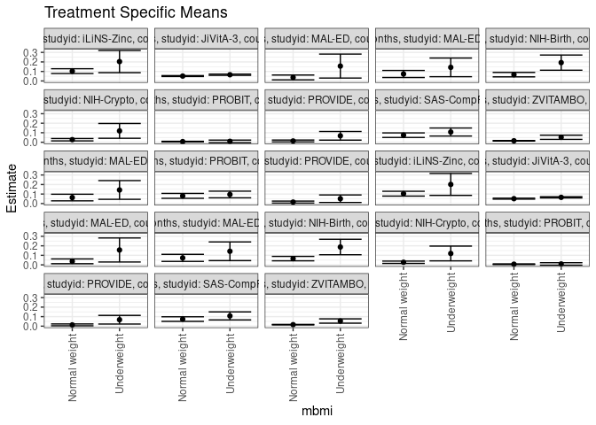

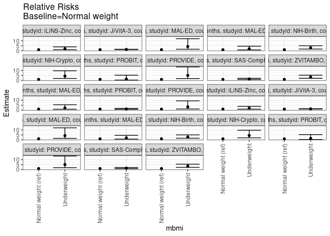

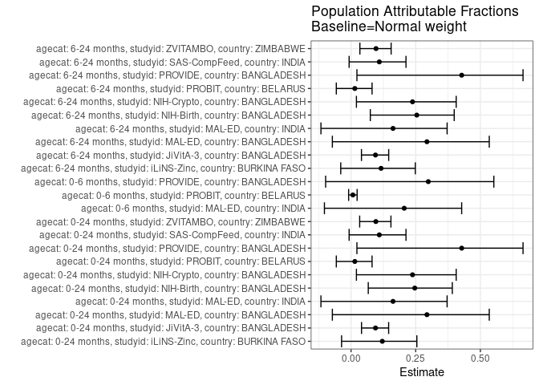

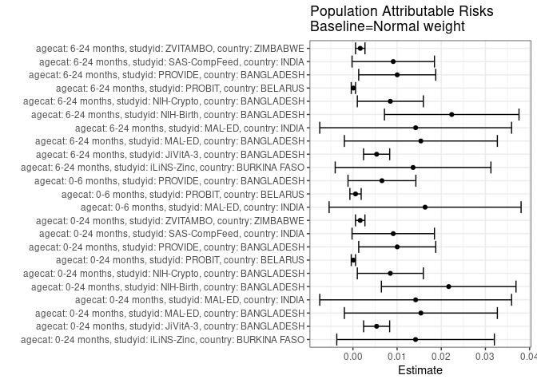

## Results Table

### Parameter: TSM

| agecat | studyid | country | intervention_level | baseline_level | estimate | ci_lower | ci_upper |
| --- | --- | --- | --- | --- | --- | --- | --- |
| 0-24 months | iLiNS-Zinc | BURKINA FASO | Normal weight | NA | 0.1031447 | 0.0780218 | 0.1282677 |
| 0-24 months | iLiNS-Zinc | BURKINA FASO | Underweight | NA | 0.2035313 | 0.0871074 | 0.3199551 |
| 0-24 months | JiVitA-3 | BANGLADESH | Normal weight | NA | 0.0514288 | 0.0463438 | 0.0565138 |
| 0-24 months | JiVitA-3 | BANGLADESH | Underweight | NA | 0.0653009 | 0.0589919 | 0.0716098 |
| 0-24 months | MAL-ED | BANGLADESH | Normal weight | NA | 0.0370370 | 0.0118010 | 0.0622731 |
| 0-24 months | MAL-ED | BANGLADESH | Underweight | NA | 0.1562500 | 0.0301929 | 0.2823071 |
| 0-24 months | MAL-ED | INDIA | Normal weight | NA | 0.0732984 | 0.0362598 | 0.1103371 |
| 0-24 months | MAL-ED | INDIA | Underweight | NA | 0.1428571 | 0.0446746 | 0.2410397 |
| 0-24 months | NIH-Birth | BANGLADESH | Normal weight | NA | 0.0663309 | 0.0430218 | 0.0896400 |
| 0-24 months | NIH-Birth | BANGLADESH | Underweight | NA | 0.1925760 | 0.1127814 | 0.2723705 |
| 0-24 months | NIH-Crypto | BANGLADESH | Normal weight | NA | 0.0271493 | 0.0147701 | 0.0395285 |
| 0-24 months | NIH-Crypto | BANGLADESH | Underweight | NA | 0.1194030 | 0.0417059 | 0.1971000 |
| 0-24 months | PROBIT | BELARUS | Normal weight | NA | 0.0068981 | 0.0037765 | 0.0100197 |
| 0-24 months | PROBIT | BELARUS | Underweight | NA | 0.0095785 | -0.0034154 | 0.0225725 |
| 0-24 months | PROVIDE | BANGLADESH | Normal weight | NA | 0.0134100 | 0.0035350 | 0.0232849 |
| 0-24 months | PROVIDE | BANGLADESH | Underweight | NA | 0.0677966 | 0.0224018 | 0.1131914 |
| 0-24 months | SAS-CompFeed | INDIA | Normal weight | NA | 0.0744045 | 0.0504081 | 0.0984008 |
| 0-24 months | SAS-CompFeed | INDIA | Underweight | NA | 0.1075385 | 0.0654231 | 0.1496538 |
| 0-24 months | ZVITAMBO | ZIMBABWE | Normal weight | NA | 0.0155189 | 0.0127620 | 0.0182758 |
| 0-24 months | ZVITAMBO | ZIMBABWE | Underweight | NA | 0.0523449 | 0.0302295 | 0.0744602 |
| 0-6 months | MAL-ED | INDIA | Normal weight | NA | 0.0631579 | 0.0284979 | 0.0978179 |
| 0-6 months | MAL-ED | INDIA | Underweight | NA | 0.1428571 | 0.0446737 | 0.2410406 |
| 0-6 months | PROBIT | BELARUS | Normal weight | NA | 0.0807696 | 0.0549902 | 0.1065489 |
| 0-6 months | PROBIT | BELARUS | Underweight | NA | 0.0952743 | 0.0602749 | 0.1302737 |
| 0-6 months | PROVIDE | BANGLADESH | Normal weight | NA | 0.0154143 | 0.0048072 | 0.0260213 |
| 0-6 months | PROVIDE | BANGLADESH | Underweight | NA | 0.0508475 | 0.0111785 | 0.0905164 |
| 6-24 months | iLiNS-Zinc | BURKINA FASO | Normal weight | NA | 0.1037121 | 0.0784712 | 0.1289530 |
| 6-24 months | iLiNS-Zinc | BURKINA FASO | Underweight | NA | 0.2010452 | 0.0858198 | 0.3162707 |
| 6-24 months | JiVitA-3 | BANGLADESH | Normal weight | NA | 0.0514293 | 0.0463216 | 0.0565370 |
| 6-24 months | JiVitA-3 | BANGLADESH | Underweight | NA | 0.0653143 | 0.0589357 | 0.0716930 |
| 6-24 months | MAL-ED | BANGLADESH | Normal weight | NA | 0.0370370 | 0.0118010 | 0.0622731 |
| 6-24 months | MAL-ED | BANGLADESH | Underweight | NA | 0.1562500 | 0.0301929 | 0.2823071 |
| 6-24 months | MAL-ED | INDIA | Normal weight | NA | 0.0732984 | 0.0362598 | 0.1103371 |
| 6-24 months | MAL-ED | INDIA | Underweight | NA | 0.1428571 | 0.0446746 | 0.2410397 |
| 6-24 months | NIH-Birth | BANGLADESH | Normal weight | NA | 0.0656454 | 0.0424049 | 0.0888860 |
| 6-24 months | NIH-Birth | BANGLADESH | Underweight | NA | 0.1874158 | 0.1061297 | 0.2687019 |
| 6-24 months | NIH-Crypto | BANGLADESH | Normal weight | NA | 0.0271493 | 0.0147701 | 0.0395285 |
| 6-24 months | NIH-Crypto | BANGLADESH | Underweight | NA | 0.1194030 | 0.0417059 | 0.1971000 |
| 6-24 months | PROBIT | BELARUS | Normal weight | NA | 0.0068981 | 0.0037765 | 0.0100197 |
| 6-24 months | PROBIT | BELARUS | Underweight | NA | 0.0095785 | -0.0034154 | 0.0225725 |
| 6-24 months | PROVIDE | BANGLADESH | Normal weight | NA | 0.0134100 | 0.0035350 | 0.0232849 |
| 6-24 months | PROVIDE | BANGLADESH | Underweight | NA | 0.0677966 | 0.0224018 | 0.1131914 |
| 6-24 months | SAS-CompFeed | INDIA | Normal weight | NA | 0.0744045 | 0.0504081 | 0.0984008 |
| 6-24 months | SAS-CompFeed | INDIA | Underweight | NA | 0.1075385 | 0.0654231 | 0.1496538 |
| 6-24 months | ZVITAMBO | ZIMBABWE | Normal weight | NA | 0.0155055 | 0.0127503 | 0.0182606 |
| 6-24 months | ZVITAMBO | ZIMBABWE | Underweight | NA | 0.0539083 | 0.0313109 | 0.0765057 |

### Parameter: E(Y)

| agecat | studyid | country | intervention_level | baseline_level | estimate | ci_lower | ci_upper |
| --- | --- | --- | --- | --- | --- | --- | --- |
| 0-24 months | iLiNS-Zinc | BURKINA FASO | NA | NA | 0.1173252 | 0.0921861 | 0.1424644 |
| 0-24 months | JiVitA-3 | BANGLADESH | NA | NA | 0.0567929 | 0.0526539 | 0.0609319 |
| 0-24 months | MAL-ED | BANGLADESH | NA | NA | 0.0524194 | 0.0246252 | 0.0802135 |
| 0-24 months | MAL-ED | INDIA | NA | NA | 0.0875000 | 0.0516764 | 0.1233236 |
| 0-24 months | NIH-Birth | BANGLADESH | NA | NA | 0.0880150 | 0.0639627 | 0.1120673 |
| 0-24 months | NIH-Crypto | BANGLADESH | NA | NA | 0.0356164 | 0.0221630 | 0.0490699 |
| 0-24 months | PROBIT | BELARUS | NA | NA | 0.0070001 | 0.0038704 | 0.0101299 |
| 0-24 months | PROVIDE | BANGLADESH | NA | NA | 0.0234375 | 0.0117074 | 0.0351676 |
| 0-24 months | SAS-CompFeed | INDIA | NA | NA | 0.0835322 | 0.0594080 | 0.1076564 |
| 0-24 months | ZVITAMBO | ZIMBABWE | NA | NA | 0.0171632 | 0.0143445 | 0.0199819 |
| 0-6 months | MAL-ED | INDIA | NA | NA | 0.0794979 | 0.0451303 | 0.1138656 |
| 0-6 months | PROBIT | BELARUS | NA | NA | 0.0813564 | 0.0559260 | 0.1067869 |
| 0-6 months | PROVIDE | BANGLADESH | NA | NA | 0.0219780 | 0.0105837 | 0.0333723 |
| 6-24 months | iLiNS-Zinc | BURKINA FASO | NA | NA | 0.1173252 | 0.0921861 | 0.1424644 |
| 6-24 months | JiVitA-3 | BANGLADESH | NA | NA | 0.0567929 | 0.0526539 | 0.0609319 |
| 6-24 months | MAL-ED | BANGLADESH | NA | NA | 0.0524194 | 0.0246252 | 0.0802135 |
| 6-24 months | MAL-ED | INDIA | NA | NA | 0.0875000 | 0.0516764 | 0.1233236 |
| 6-24 months | NIH-Birth | BANGLADESH | NA | NA | 0.0880150 | 0.0639627 | 0.1120673 |
| 6-24 months | NIH-Crypto | BANGLADESH | NA | NA | 0.0356164 | 0.0221630 | 0.0490699 |
| 6-24 months | PROBIT | BELARUS | NA | NA | 0.0070001 | 0.0038704 | 0.0101299 |
| 6-24 months | PROVIDE | BANGLADESH | NA | NA | 0.0234375 | 0.0117074 | 0.0351676 |
| 6-24 months | SAS-CompFeed | INDIA | NA | NA | 0.0835322 | 0.0594080 | 0.1076564 |
| 6-24 months | ZVITAMBO | ZIMBABWE | NA | NA | 0.0171632 | 0.0143445 | 0.0199819 |

### Parameter: RR

| agecat | studyid | country | intervention_level | baseline_level | estimate | ci_lower | ci_upper |
| --- | --- | --- | --- | --- | --- | --- | --- |
| 0-24 months | iLiNS-Zinc | BURKINA FASO | Normal weight | Normal weight | 1.000000 | 1.0000000 | 1.000000 |
| 0-24 months | iLiNS-Zinc | BURKINA FASO | Underweight | Normal weight | 1.973259 | 1.0036615 | 3.879545 |
| 0-24 months | JiVitA-3 | BANGLADESH | Normal weight | Normal weight | 1.000000 | 1.0000000 | 1.000000 |
| 0-24 months | JiVitA-3 | BANGLADESH | Underweight | Normal weight | 1.269734 | 1.1142219 | 1.446951 |
| 0-24 months | MAL-ED | BANGLADESH | Normal weight | Normal weight | 1.000000 | 1.0000000 | 1.000000 |
| 0-24 months | MAL-ED | BANGLADESH | Underweight | Normal weight | 4.218750 | 1.4674655 | 12.128293 |
| 0-24 months | MAL-ED | INDIA | Normal weight | Normal weight | 1.000000 | 1.0000000 | 1.000000 |
| 0-24 months | MAL-ED | INDIA | Underweight | Normal weight | 1.948980 | 0.8304871 | 4.573848 |
| 0-24 months | NIH-Birth | BANGLADESH | Normal weight | Normal weight | 1.000000 | 1.0000000 | 1.000000 |
| 0-24 months | NIH-Birth | BANGLADESH | Underweight | Normal weight | 2.903263 | 1.6848822 | 5.002686 |
| 0-24 months | NIH-Crypto | BANGLADESH | Normal weight | Normal weight | 1.000000 | 1.0000000 | 1.000000 |
| 0-24 months | NIH-Crypto | BANGLADESH | Underweight | Normal weight | 4.398010 | 1.9869244 | 9.734890 |
| 0-24 months | PROBIT | BELARUS | Normal weight | Normal weight | 1.000000 | 1.0000000 | 1.000000 |
| 0-24 months | PROBIT | BELARUS | Underweight | Normal weight | 1.388573 | 0.3622102 | 5.323249 |
| 0-24 months | PROVIDE | BANGLADESH | Normal weight | Normal weight | 1.000000 | 1.0000000 | 1.000000 |
| 0-24 months | PROVIDE | BANGLADESH | Underweight | Normal weight | 5.055690 | 1.8686708 | 13.678173 |
| 0-24 months | SAS-CompFeed | INDIA | Normal weight | Normal weight | 1.000000 | 1.0000000 | 1.000000 |
| 0-24 months | SAS-CompFeed | INDIA | Underweight | Normal weight | 1.445323 | 0.9914735 | 2.106922 |
| 0-24 months | ZVITAMBO | ZIMBABWE | Normal weight | Normal weight | 1.000000 | 1.0000000 | 1.000000 |
| 0-24 months | ZVITAMBO | ZIMBABWE | Underweight | Normal weight | 3.372976 | 2.1330075 | 5.333768 |
| 0-6 months | MAL-ED | INDIA | Normal weight | Normal weight | 1.000000 | 1.0000000 | 1.000000 |
| 0-6 months | MAL-ED | INDIA | Underweight | Normal weight | 2.261905 | 0.9386674 | 5.450507 |
| 0-6 months | PROBIT | BELARUS | Normal weight | Normal weight | 1.000000 | 1.0000000 | 1.000000 |
| 0-6 months | PROBIT | BELARUS | Underweight | Normal weight | 1.179582 | 0.8098260 | 1.718163 |
| 0-6 months | PROVIDE | BANGLADESH | Normal weight | Normal weight | 1.000000 | 1.0000000 | 1.000000 |
| 0-6 months | PROVIDE | BANGLADESH | Underweight | Normal weight | 3.298729 | 1.1656329 | 9.335368 |
| 6-24 months | iLiNS-Zinc | BURKINA FASO | Normal weight | Normal weight | 1.000000 | 1.0000000 | 1.000000 |
| 6-24 months | iLiNS-Zinc | BURKINA FASO | Underweight | Normal weight | 1.938493 | 0.9881728 | 3.802732 |
| 6-24 months | JiVitA-3 | BANGLADESH | Normal weight | Normal weight | 1.000000 | 1.0000000 | 1.000000 |
| 6-24 months | JiVitA-3 | BANGLADESH | Underweight | Normal weight | 1.269982 | 1.1135291 | 1.448418 |
| 6-24 months | MAL-ED | BANGLADESH | Normal weight | Normal weight | 1.000000 | 1.0000000 | 1.000000 |
| 6-24 months | MAL-ED | BANGLADESH | Underweight | Normal weight | 4.218750 | 1.4674655 | 12.128293 |
| 6-24 months | MAL-ED | INDIA | Normal weight | Normal weight | 1.000000 | 1.0000000 | 1.000000 |
| 6-24 months | MAL-ED | INDIA | Underweight | Normal weight | 1.948980 | 0.8304871 | 4.573848 |
| 6-24 months | NIH-Birth | BANGLADESH | Normal weight | Normal weight | 1.000000 | 1.0000000 | 1.000000 |
| 6-24 months | NIH-Birth | BANGLADESH | Underweight | Normal weight | 2.854972 | 1.6296328 | 5.001657 |
| 6-24 months | NIH-Crypto | BANGLADESH | Normal weight | Normal weight | 1.000000 | 1.0000000 | 1.000000 |
| 6-24 months | NIH-Crypto | BANGLADESH | Underweight | Normal weight | 4.398010 | 1.9869244 | 9.734890 |
| 6-24 months | PROBIT | BELARUS | Normal weight | Normal weight | 1.000000 | 1.0000000 | 1.000000 |
| 6-24 months | PROBIT | BELARUS | Underweight | Normal weight | 1.388573 | 0.3622102 | 5.323249 |
| 6-24 months | PROVIDE | BANGLADESH | Normal weight | Normal weight | 1.000000 | 1.0000000 | 1.000000 |
| 6-24 months | PROVIDE | BANGLADESH | Underweight | Normal weight | 5.055690 | 1.8686708 | 13.678173 |
| 6-24 months | SAS-CompFeed | INDIA | Normal weight | Normal weight | 1.000000 | 1.0000000 | 1.000000 |
| 6-24 months | SAS-CompFeed | INDIA | Underweight | Normal weight | 1.445323 | 0.9914735 | 2.106922 |
| 6-24 months | ZVITAMBO | ZIMBABWE | Normal weight | Normal weight | 1.000000 | 1.0000000 | 1.000000 |
| 6-24 months | ZVITAMBO | ZIMBABWE | Underweight | Normal weight | 3.476726 | 2.2053475 | 5.481052 |

### Parameter: PAR

| agecat | studyid | country | intervention_level | baseline_level | estimate | ci_lower | ci_upper |
| --- | --- | --- | --- | --- | --- | --- | --- |
| 0-24 months | iLiNS-Zinc | BURKINA FASO | Normal weight | NA | 0.0141805 | -0.0036617 | 0.0320227 |
| 0-24 months | JiVitA-3 | BANGLADESH | Normal weight | NA | 0.0053642 | 0.0024149 | 0.0083135 |
| 0-24 months | MAL-ED | BANGLADESH | Normal weight | NA | 0.0153823 | -0.0019384 | 0.0327030 |
| 0-24 months | MAL-ED | INDIA | Normal weight | NA | 0.0142016 | -0.0075159 | 0.0359190 |
| 0-24 months | NIH-Birth | BANGLADESH | Normal weight | NA | 0.0216841 | 0.0064464 | 0.0369218 |
| 0-24 months | NIH-Crypto | BANGLADESH | Normal weight | NA | 0.0084671 | 0.0009917 | 0.0159425 |
| 0-24 months | PROBIT | BELARUS | Normal weight | NA | 0.0001020 | -0.0003837 | 0.0005878 |
| 0-24 months | PROVIDE | BANGLADESH | Normal weight | NA | 0.0100275 | 0.0013074 | 0.0187476 |
| 0-24 months | SAS-CompFeed | INDIA | Normal weight | NA | 0.0091278 | -0.0002050 | 0.0184605 |
| 0-24 months | ZVITAMBO | ZIMBABWE | Normal weight | NA | 0.0016443 | 0.0005745 | 0.0027141 |
| 0-6 months | MAL-ED | INDIA | Normal weight | NA | 0.0163400 | -0.0053950 | 0.0380750 |
| 0-6 months | PROBIT | BELARUS | Normal weight | NA | 0.0005869 | -0.0006889 | 0.0018626 |
| 0-6 months | PROVIDE | BANGLADESH | Normal weight | NA | 0.0065638 | -0.0011177 | 0.0142452 |
| 6-24 months | iLiNS-Zinc | BURKINA FASO | Normal weight | NA | 0.0136131 | -0.0040180 | 0.0312442 |
| 6-24 months | JiVitA-3 | BANGLADESH | Normal weight | NA | 0.0053636 | 0.0024033 | 0.0083240 |
| 6-24 months | MAL-ED | BANGLADESH | Normal weight | NA | 0.0153823 | -0.0019384 | 0.0327030 |
| 6-24 months | MAL-ED | INDIA | Normal weight | NA | 0.0142016 | -0.0075159 | 0.0359190 |
| 6-24 months | NIH-Birth | BANGLADESH | Normal weight | NA | 0.0223696 | 0.0071358 | 0.0376034 |
| 6-24 months | NIH-Crypto | BANGLADESH | Normal weight | NA | 0.0084671 | 0.0009917 | 0.0159425 |
| 6-24 months | PROBIT | BELARUS | Normal weight | NA | 0.0001020 | -0.0003837 | 0.0005878 |
| 6-24 months | PROVIDE | BANGLADESH | Normal weight | NA | 0.0100275 | 0.0013074 | 0.0187476 |
| 6-24 months | SAS-CompFeed | INDIA | Normal weight | NA | 0.0091278 | -0.0002050 | 0.0184605 |
| 6-24 months | ZVITAMBO | ZIMBABWE | Normal weight | NA | 0.0016577 | 0.0005880 | 0.0027274 |

### Parameter: PAF

| agecat | studyid | country | intervention_level | baseline_level | estimate | ci_lower | ci_upper |
| --- | --- | --- | --- | --- | --- | --- | --- |
| 0-24 months | iLiNS-Zinc | BURKINA FASO | Normal weight | NA | 0.1208648 | -0.0366564 | 0.2544505 |
| 0-24 months | JiVitA-3 | BANGLADESH | Normal weight | NA | 0.0944514 | 0.0405136 | 0.1453572 |
| 0-24 months | MAL-ED | BANGLADESH | Normal weight | NA | 0.2934473 | -0.0722695 | 0.5344298 |
| 0-24 months | MAL-ED | INDIA | Normal weight | NA | 0.1623037 | -0.1164315 | 0.3714481 |
| 0-24 months | NIH-Birth | BANGLADESH | Normal weight | NA | 0.2463684 | 0.0665674 | 0.3915355 |
| 0-24 months | NIH-Crypto | BANGLADESH | Normal weight | NA | 0.2377306 | 0.0208001 | 0.4066026 |
| 0-24 months | PROBIT | BELARUS | Normal weight | NA | 0.0145748 | -0.0569888 | 0.0812932 |
| 0-24 months | PROVIDE | BANGLADESH | Normal weight | NA | 0.4278416 | 0.0226926 | 0.6650335 |
| 0-24 months | SAS-CompFeed | INDIA | Normal weight | NA | 0.1092723 | -0.0073879 | 0.2124227 |
| 0-24 months | ZVITAMBO | ZIMBABWE | Normal weight | NA | 0.0958026 | 0.0333373 | 0.1542313 |
| 0-6 months | MAL-ED | INDIA | Normal weight | NA | 0.2055402 | -0.1029502 | 0.4277471 |
| 0-6 months | PROBIT | BELARUS | Normal weight | NA | 0.0072135 | -0.0093143 | 0.0234706 |
| 0-6 months | PROVIDE | BANGLADESH | Normal weight | NA | 0.2986513 | -0.0982640 | 0.5521204 |
| 6-24 months | iLiNS-Zinc | BURKINA FASO | Normal weight | NA | 0.1160289 | -0.0399043 | 0.2485801 |
| 6-24 months | JiVitA-3 | BANGLADESH | Normal weight | NA | 0.0944420 | 0.0402507 | 0.1455735 |
| 6-24 months | MAL-ED | BANGLADESH | Normal weight | NA | 0.2934473 | -0.0722695 | 0.5344298 |
| 6-24 months | MAL-ED | INDIA | Normal weight | NA | 0.1623037 | -0.1164315 | 0.3714481 |
| 6-24 months | NIH-Birth | BANGLADESH | Normal weight | NA | 0.2541564 | 0.0745089 | 0.3989323 |
| 6-24 months | NIH-Crypto | BANGLADESH | Normal weight | NA | 0.2377306 | 0.0208001 | 0.4066026 |
| 6-24 months | PROBIT | BELARUS | Normal weight | NA | 0.0145748 | -0.0569888 | 0.0812932 |
| 6-24 months | PROVIDE | BANGLADESH | Normal weight | NA | 0.4278416 | 0.0226926 | 0.6650335 |
| 6-24 months | SAS-CompFeed | INDIA | Normal weight | NA | 0.1092723 | -0.0073879 | 0.2124227 |
| 6-24 months | ZVITAMBO | ZIMBABWE | Normal weight | NA | 0.0965851 | 0.0341485 | 0.1549855 |